# K-Nearest Neighbours

*K-Nearest Neighbours Overview:*

The K-Nearest Neighbors (KNN) algorithm is a non parametric, supervised learning method used for both classification and regression tasks. It was first developed by Evelyn Fix and Joseph Hodges in 1951, and later expanded by Thomas Cover. It makes predictions based on the similarity (proximity) of a data point to its k nearest neighbors in the feature space. The algorithm follows a lazy learning approach, meaning it does not learn an explicit model but makes predictions by storing and comparing data points.

*K-Nearest Neighbours Classifier:*

The K-Nearest Neighbors (KNN) classifier is a supervised learning algorithm primarily used for classification tasks. It operates by identifying the k-nearest data points (neighbors) to a query point within a feature space, based on a specified distance metric (e.g., Euclidean, Manhattan, or Minkowski distance). The class of the query point is then determined by a majority vote among its neighbors. The choice of k (the number of neighbors) significantly impacts the model's performance:

- Small k values lead to high variance, making the classifier sensitive to noise (overfitting).
- Large k values provide a smoother decision boundary but may lead to underfitting, ignoring local patterns.

*K-Nearest Neighbours Regressor:*

The K-Nearest Neighbors (KNN) regressor extends the algorithm to regression tasks, predicting continuous values instead of class labels. In KNN regression, the output value for a query point is computed as the average (or sometimes weighted average) of the values of its k nearest neighbors. This technique, also known as nearest neighbor smoothing, is useful for making predictions in complex datasets where the relationship between features and target variables is nonlinear and non-parametric.

Key features of KNN Regressor:

- Simplicity – Easy to implement and understand, with minimal assumptions about the data.
- Versatility – Effective for a wide range of regression problems.
- Sensitivity to k and distance metric – Choice of k and distance metric can greatly impact performance.

*Choosing k in KNN:*

- Cross-Validation: A robust method for selecting the best k is to perform k-fold cross-validation. This involves splitting the data into k subsets training the model on some subsets and testing it on the remaining ones and repeating this for each subset. The value of k that results in the highest average validation accuracy is usually the best choice.
- Elbow Method: In the elbow method we plot the model’s error rate or accuracy for different values of k. As we increase k the error usually decreases initially. However after a certain point the error rate starts to decrease more slowly. This point where the curve forms an “elbow” that point is considered as best k.

*Advantages of KNN*

- Non-parametric: No assumptions about data distribution.
- Intuitive and interpretable: Easy to understand and implement.
- Versatile: Applicable to both classification and regression tasks.

*Limitations of KNN*

- Computationally expensive: High cost for large datasets due to distance calculation for each query.
- Sensitive to feature scaling: Requires normalization or standardization of data.
- Memory intensive: Stores entire training data for making predictions.

*Applications of KNN:*

Datasets Where KNN Struggles:

- High-Dimensional Data: Curse of dimensionality makes distance calculations unreliable. Use PCA or feature selection to reduce dimensions.
- Imbalanced Datasets: If one class is much more frequent than others, KNN may be biased. Consider SMOTE or class weighting.
- Big Datasets: Since KNN needs to compute distances for every query, large datasets make it computationally expensive. Use Approximate Nearest Neighbors (ANN) or tree-based methods instead.

So, KNN works effectively on structured data where features are well-defined.

KNN is widely used in various domains due to its simplicity and effectiveness. Some key applications include:

- Recommendation Systems – Used in collaborative filtering to suggest products or content based on user similarity (e.g., Netflix, Amazon).
- Image Recognition – Classifies images based on pixel similarities (e.g., handwritten digit recognition using MNIST dataset).
- Medical Diagnosis – Assists in disease prediction by comparing patient symptoms with historical data (e.g., cancer diagnosis).
- Financial Fraud Detection – Identifies fraudulent transactions by analyzing similarities with past fraudulent activities.
- Customer Segmentation – Groups similar customers based on purchasing behavior for targeted marketing.
- Anomaly Detection – Detects outliers in network security and intrusion detection systems.
- Speech Recognition – Matches speech patterns with known samples to recognize spoken words.

## References:

https://link.springer.com/chapter/10.1007/978-981-97-5489-2_13

https://ieeexplore.ieee.org/abstract/document/8776969

https://www.sciencedirect.com/science/article/abs/pii/S0031320318301985

https://www.geeksforgeeks.org/k-nearest-neighbours/

### Algorithm Steps:

- Choose the number of neighbors k.
- Compute the distance between the query point and all training points.
- Identify the k-nearest neighbors.
- For classification: Assign the most frequent class among the neighbors.
- For regression: Compute the average (or weighted average) of the neighbors' values.
- Return the predicted class (classification) or value (regression).

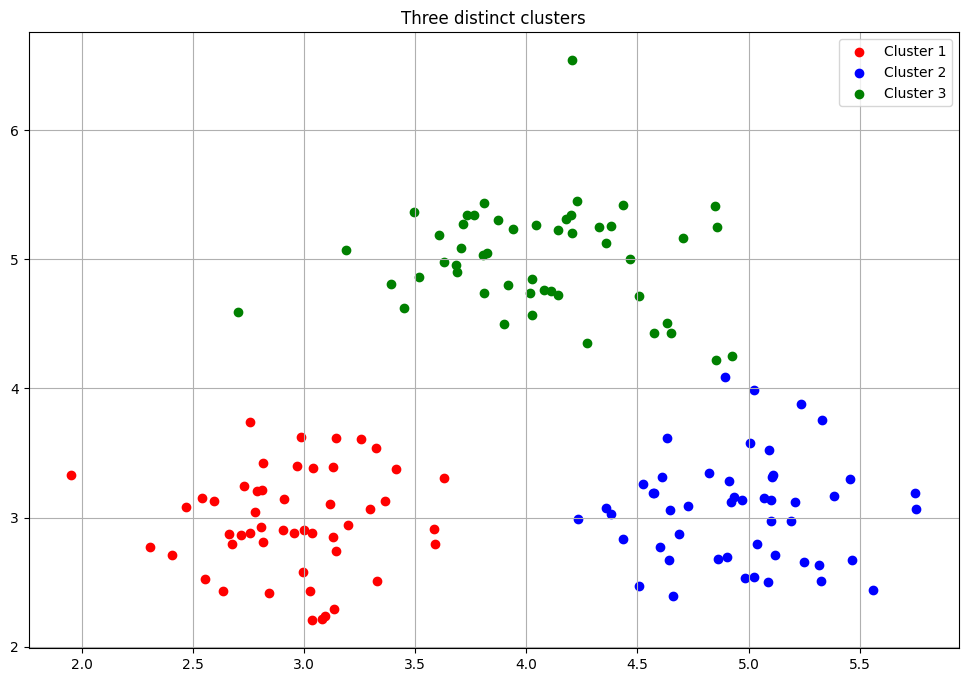

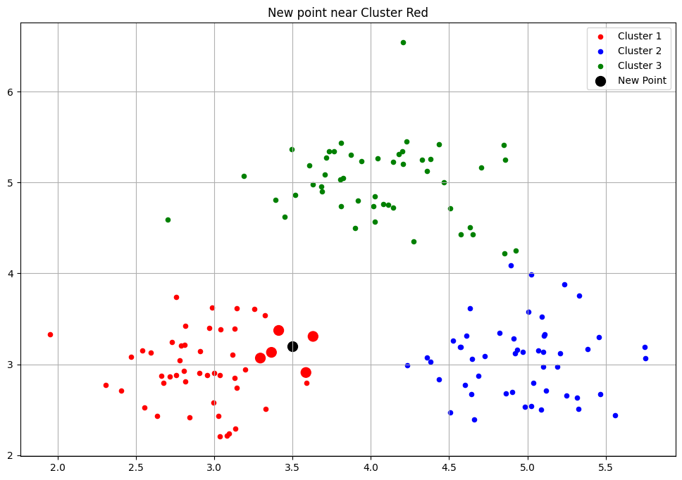

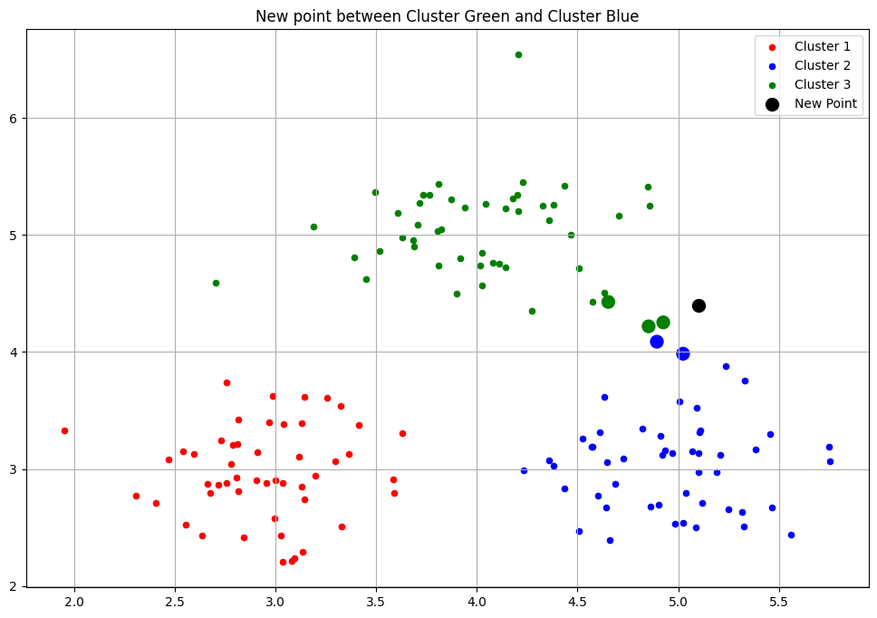

```python
import matplotlib.pyplot as plt
import numpy as np

np.random.seed(42)
cluster1 = np.random.normal(loc=[3, 3], scale=0.4, size=(50, 2))
cluster2 = np.random.normal(loc=[5, 3], scale=0.4, size=(50, 2))
cluster3 = np.random.normal(loc=[4, 5], scale=0.4, size=(50, 2))

plt.figure(figsize=(12, 8))
plt.scatter(cluster1[:, 0], cluster1[:, 1], color='red', label='Cluster 1')
plt.scatter(cluster2[:, 0], cluster2[:, 1], color='blue', label='Cluster 2')
plt.scatter(cluster3[:, 0], cluster3[:, 1], color='green', label='Cluster 3')
plt.title('Three distinct clusters')
plt.legend()
plt.grid()
plt.show()

all_points = np.vstack([cluster1, cluster2, cluster3])
colors = ['red'] * 50 + ['blue'] * 50 + ['green'] * 50

def find_nearest_neighbors(point, all_points, k=5):
    distances = np.linalg.norm(all_points - np.array(point), axis=1)
    nearest_indices = np.argsort(distances)[:k]
    return nearest_indices

near_point = [3.5, 3.2]
nearest_indices = find_nearest_neighbors(near_point, all_points)
plt.figure(figsize=(12, 8))
plt.scatter(cluster1[:, 0], cluster1[:, 1], color='red', label='Cluster 1', s=20)
plt.scatter(cluster2[:, 0], cluster2[:, 1], color='blue', label='Cluster 2', s=20)
plt.scatter(cluster3[:, 0], cluster3[:, 1], color='green', label='Cluster 3', s=20)
plt.scatter(near_point[0], near_point[1], color='black', s=100, label='New Point')

plt.scatter(all_points[nearest_indices, 0], all_points[nearest_indices, 1], color=[colors[i] for i in nearest_indices], s=100)
plt.title('New point near Cluster Red')
plt.legend()
plt.grid()
plt.show()

between_point = [5.1, 4.4]
nearest_indices = find_nearest_neighbors(between_point, all_points)
plt.figure(figsize=(12, 8))
plt.scatter(cluster1[:, 0], cluster1[:, 1], color='red', label='Cluster 1', s=20)
plt.scatter(cluster2[:, 0], cluster2[:, 1], color='blue', label='Cluster 2', s=20)
plt.scatter(cluster3[:, 0], cluster3[:, 1], color='green', label='Cluster 3', s=20)
plt.scatter(between_point[0], between_point[1], color='black', s=100, label='New Point')

plt.scatter(all_points[nearest_indices, 0], all_points[nearest_indices, 1], color=[colors[i] for i in nearest_indices], s=100)
plt.title('New point between Cluster Green and Cluster Blue')
plt.legend()
plt.grid()
plt.show()
```

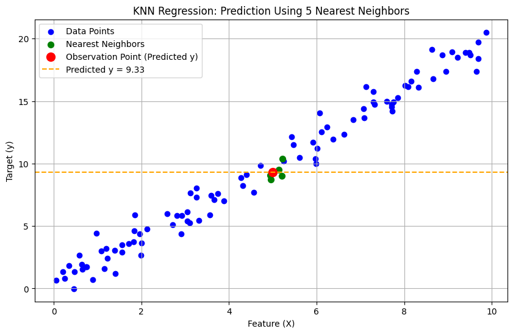

```python
import numpy as np
import matplotlib.pyplot as plt

np.random.seed(42)
X = np.random.rand(100, 1) * 10
y = 2 * X.squeeze() + np.random.randn(100)

obs_x = 5
obs_y_actual = 2 * obs_x

distances = np.abs(X.squeeze() - obs_x)
nearest_neighbors_indices = np.argsort(distances)[:5]

nearest_neighbors_y = y[nearest_neighbors_indices]
predicted_y = np.mean(nearest_neighbors_y)

plt.figure(figsize=(10, 6))
plt.scatter(X, y, color='blue', label='Data Points')

plt.scatter(X[nearest_neighbors_indices], nearest_neighbors_y, color='green', s=50, label='Nearest Neighbors')
plt.scatter([obs_x], [predicted_y], color='red', s=100, label='Observation Point (Predicted y)')

plt.axhline(predicted_y, color='orange', linestyle='--', label=f'Predicted y = {predicted_y:.2f}')

plt.title("KNN Regression: Prediction Using 5 Nearest Neighbors")
plt.xlabel("Feature (X)")
plt.ylabel("Target (y)")
plt.legend()
plt.grid()
plt.show()
```

### Mathematical Formulation

Let:

- $X = \{ x_1, x_2, \dots, x_n \}$ be the set of training examples.
- $Y = \{ y_1, y_2, \dots, y_n \}$ be the corresponding labels (for classification) or continuous values (for regression).
- $q$ be the query point (the new instance for which we need a prediction).
- $k$ be the number of nearest neighbors to consider.
- $d(x_i, q)$ be a distance function measuring proximity between points.

### 1. Distance Calculation

To determine the $k$-nearest neighbors of $q$, we use a distance metric such as:

#### **Euclidean Distance** (default in most cases):

Euclidean Distance is the most common way to calculate the distance between an observation and other data points. It measures the straight-line distance between 2 points.

$d(x_i, q) = \sqrt{\sum_{j=1}^{m} (x_{ij} - q_j)^2}$  
where $m$ is the number of features.

#### **Manhattan Distance**:

Manhattan distance sums the absolute differences between the coordinates of two points.

$d(x_i, q) = \sum_{j=1}^{m} |x_{ij} - q_j|$

### KNN for Classification

1. Compute the distance $d(x_i, q)$ for all training points $x_i$.
2. Select the $k$ nearest neighbors with the smallest distances.
3. Assign the class label to $q$ using a majority vote among these $k$ neighbors:

$$ \hat{y} = \arg \max_c \sum_{i \in N_k(q)} I(y_i = c) $$

Where:

- $N_k(q)$ is the set of $k$ nearest neighbors.
- $I(y_i = c)$ is an indicator function that equals 1 if $y_i = c$ and 0 otherwise.
- $\hat{y}$ is the predicted class.

### KNN for Regression

1. Compute the distance $d(x_i, q)$ for all training points.
2. Select the $k$ nearest neighbors.
3. Compute the predicted value as the mean (or weighted mean) of the $k$ neighbors' target values:

$$ \hat{y} = \frac{1}{k} \sum_{i \in N_k(q)} y_i $$

Alternatively, a weighted average can be used where closer neighbors contribute more:

$$ \hat{y} = \frac{\sum_{i \in N_k(q)} w_i y_i}{\sum_{i \in N_k(q)} w_i} $$

Where:

- $w_i = \frac{1}{d(x_i, q)}$ is an inverse distance weight.
- $\hat{y}$ is the predicted value.

# Classification using KNN

## 1. Importing the necessary libraries

```python
import pandas as pd
import numpy as np
import seaborn as sns
from sklearn.preprocessing import StandardScaler
from sklearn.model_selection import train_test_split
import matplotlib.pyplot as plt
from sklearn import datasets
from sklearn.datasets import load_iris
from sklearn.model_selection import train_test_split, GridSearchCV,StratifiedShuffleSplit
from sklearn.neighbors import KNeighborsClassifier
from sklearn.neighbors import KNeighborsRegressor
from sklearn.metrics import mean_squared_error, r2_score, classification_report, confusion_matrix, f1_score, make_scorer, accuracy_score
```

## 2. Loading the dataset

We will be using the Iris dataset present in the sklearn module for the demonstration of classification using KNN.

```python
iris = load_iris()
df = pd.DataFrame(iris.data, columns=iris.feature_names)
feature_names = iris.feature_names

df['species'] = iris.target
df['species'] = df['species'].map({0: 'setosa', 1: 'versicolor', 2: 'virginica'})
```

```python
X = pd.DataFrame(iris.data, columns=iris.feature_names)
y = pd.Series(iris.target, name='target')

print("Features (X):")
print(X.head())
print("\nTarget (y):")
print(y.head())
```

```
Features (X):
   sepal length (cm)  sepal width (cm)  petal length (cm)  petal width (cm)
0                5.1               3.5                1.4               0.2
1                4.9               3.0                1.4               0.2
2                4.7               3.2                1.3               0.2
3                4.6               3.1                1.5               0.2
4                5.0               3.6                1.4               0.2

Target (y):
0    0
1    0
2    0
3    0
4    0
Name: target, dtype: int64
```

## 3. Visualization of the data

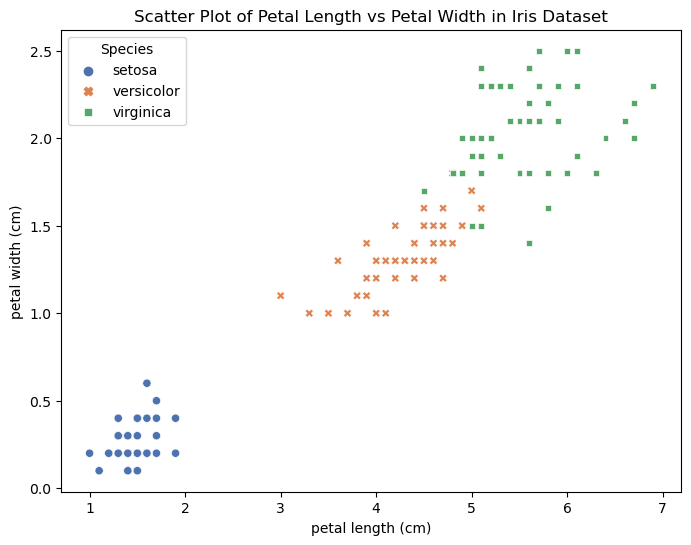

```python
plt.figure(figsize=(8, 6))
sns.scatterplot(
    x=df[feature_names[2]],
    y=df[feature_names[3]],
    hue=df['species'],
    style=df['species'],
    palette="deep"
)

plt.xlabel(feature_names[2])
plt.ylabel(feature_names[3])
plt.title("Scatter Plot of Petal Length vs Petal Width in Iris Dataset")
plt.legend(title="Species")
plt.show()
```

## 4. Splitting the data into training and testing

We are splitting the training and testing data and normalizing the resultant train and test features using Standardscaler. Normalization ensures that all features contribute equally to the distance calculations in KNN, improving classification performance.

```python
X_train, X_test, y_train, y_test = train_test_split(X, y, test_size=0.3, random_state=42, stratify=y)

scaler = StandardScaler()
X_train_normalized = scaler.fit_transform(X_train)
X_test_normalized = scaler.fit_transform(X_test)

print("Training set shape:", X_train.shape, y_train.shape)
print("Testing set shape:", X_test.shape, y_test.shape)
```

```
Training set shape: (105, 4) (105,)
Testing set shape: (45, 4) (45,)
```

## 5. Fitting the KNN model

1. **Model Training**:
   - KNeighborsClassifier(n_neighbors=3): Initializes the KNN classifier with 3 neighbors.
   - fit(X_train_normalized, y_train): Trains the model using the normalized training data.
2. **Making Predictions**:
   - predict(X_test_normalized): Uses the trained model to predict labels for the normalized test data.

```python
knn = KNeighborsClassifier(n_neighbors=3)
knn.fit(X_train_normalized, y_train)

y_pred = knn.predict(X_test_normalized)
```

## 6. Model Evaluation

We evaluate our KNN classifier by calculating its accuracy score to measure overall performance. A confusion matrix is generated to analyze how well our model distinguishes between different classes and visualize it using a heatmap for better interpretation.

Finally, we print a classification report, which provides key metrics like precision, recall, and F1-score to assess the model's effectiveness in classifying each category.

```
Accuracy: 0.87
```

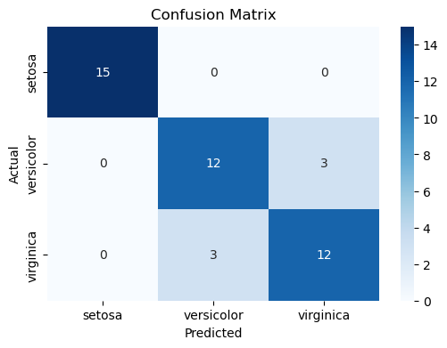

```
              precision    recall  f1-score   support

      setosa       1.00      1.00      1.00        15
  versicolor       0.80      0.80      0.80        15
   virginica       0.80      0.80      0.80        15

    accuracy                           0.87        45
   macro avg       0.87      0.87      0.87        45
weighted avg       0.87      0.87      0.87        45
```

```python
accuracy = accuracy_score(y_test, y_pred)
print(f'Accuracy: {accuracy:.2f}')

conf_matrix = confusion_matrix(y_test, y_pred)

plt.figure(figsize=(6,4))
sns.heatmap(conf_matrix, annot=True, cmap='Blues', fmt='d', xticklabels=iris.target_names, yticklabels=iris.target_names)
plt.xlabel('Predicted')
plt.ylabel('Actual')
plt.title('Confusion Matrix')
plt.show()

print(classification_report(y_test, y_pred, target_names=iris.target_names))
```

## 7. Visualizing decision boundaries

We visualize the decision boundary of our KNN classifier using two selected features (Petal Length and Petal Width) from the Iris dataset.

1. Feature Selection: We extract only the last two features (Petal Length and Petal Width) from the normalized dataset for a 2D visualization.
2. Model Training: We train a KNN classifier (k=3) using the selected features.
3. Decision Boundary Creation: We generate a mesh grid covering the entire feature space. The trained model predicts the class for each point in this grid to define the decision regions.

This helps us understand how the KNN model classifies different regions of the feature space based on petal length and petal width.

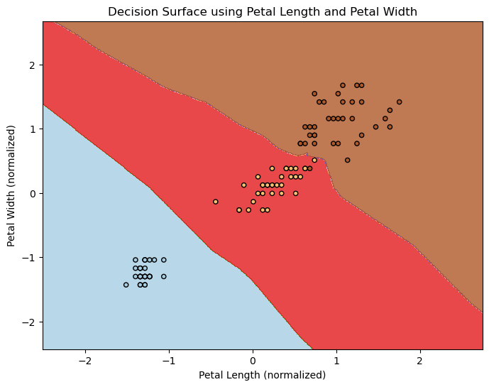

```python
X_train_2d = X_train_normalized[:, [2, 3]]
X_test_2d = X_test_normalized[:, [2, 3]]

model_2d = KNeighborsClassifier(n_neighbors=3)
model_2d.fit(X_train_2d, y_train)

x_min, x_max = X_train_2d[:, 0].min() - 1, X_train_2d[:, 0].max() + 1
y_min, y_max = X_train_2d[:, 1].min() - 1, X_train_2d[:, 1].max() + 1
xx, yy = np.meshgrid(np.arange(x_min, x_max, 0.01),
                     np.arange(y_min, y_max, 0.01))

Z = model_2d.predict(np.c_[xx.ravel(), yy.ravel()])
Z = Z.reshape(xx.shape)

plt.figure(figsize=(8, 6))
plt.contourf(xx, yy, Z, alpha=0.8, cmap=plt.cm.Paired)
plt.scatter(X_train_2d[:, 0], X_train_2d[:, 1], c=y_train, edgecolor='k', s=20, cmap=plt.cm.Paired)
plt.xlabel('Petal Length (normalized)')
plt.ylabel('Petal Width (normalized)')
plt.title('Decision Surface using Petal Length and Petal Width')
plt.show()
```

# Regression using KNN

## 1. Loading the dataset

For the demonstration of regression using KNN, we will be using the diabetes dataset present in the sklearn library.

```python
diabetes = datasets.load_diabetes()
X = diabetes.data
y = diabetes.target
```

## 2. Description of the data

The Diabetes dataset from scikit-learn is a medical dataset used for regression tasks. It contains 442 samples with 10 numerical features, representing physiological measurements and medical test results related to diabetes progression.

#### Dataset Details:

1. Target Variable (target): A continuous value representing the disease progression one year after baseline.
2. Features (X):
   - Age
   - Sex
   - Body mass index (BMI)
   - Blood pressure (BP)
   - Six blood serum measurements

```python
df = pd.DataFrame(diabetes.data, columns=diabetes.feature_names)
df['target'] = diabetes.target

print(df.head())

print(df.info())

print(df.describe())
```

```
        age       sex       bmi        bp        s1        s2        s3  \
0  0.038076  0.050680  0.061696  0.021872 -0.044223 -0.034821 -0.043401
1 -0.001882 -0.044642 -0.051474 -0.026328 -0.008449 -0.019163  0.074412
2  0.085299  0.050680  0.044451 -0.005670 -0.045599 -0.034194 -0.032356
3 -0.089063 -0.044642 -0.011595 -0.036656  0.012191  0.024991 -0.036038
4  0.005383 -0.044642 -0.036385  0.021872  0.003935  0.015596  0.008142

         s4        s5        s6  target
0 -0.002592  0.019907 -0.017646   151.0
1 -0.039493 -0.068332 -0.092204    75.0
2 -0.002592  0.002861 -0.025930   141.0
3  0.034309  0.022688 -0.009362   206.0
4 -0.002592 -0.031988 -0.046641   135.0
<class 'pandas.core.frame.DataFrame'>
RangeIndex: 442 entries, 0 to 441
Data columns (total 11 columns):
 #   Column  Non-Null Count  Dtype
---  ------  --------------  -----
 0   age     442 non-null    float64
 1   sex     442 non-null    float64
 2   bmi     442 non-null    float64
 3   bp      442 non-null    float64
 4   s1      442 non-null    float64
 5   s2      442 non-null    float64
 6   s3      442 non-null    float64
 7   s4      442 non-null    float64
 8   s5      442 non-null    float64
 9   s6      442 non-null    float64
 10  target  442 non-null    float64
dtypes: float64(11)
memory usage: 38.1 KB
None
                age           sex           bmi            bp            s1  \
count  4.420000e+02  4.420000e+02  4.420000e+02  4.420000e+02  4.420000e+02
mean  -2.511817e-19  1.230790e-17 -2.245564e-16 -4.797570e-17 -1.381499e-17
std    4.761905e-02  4.761905e-02  4.761905e-02  4.761905e-02  4.761905e-02
min   -1.072256e-01 -4.464164e-02 -9.027530e-02 -1.123988e-01 -1.267807e-01
25%   -3.729927e-02 -4.464164e-02 -3.422907e-02 -3.665608e-02 -3.424784e-02
50%    5.383060e-03 -4.464164e-02 -7.283766e-03 -5.670422e-03 -4.320866e-03
75%    3.807591e-02  5.068012e-02  3.124802e-02  3.564379e-02  2.835801e-02
max    1.107267e-01  5.068012e-02  1.705552e-01  1.320436e-01  1.539137e-01

                 s2            s3            s4            s5            s6  \
count  4.420000e+02  4.420000e+02  4.420000e+02  4.420000e+02  4.420000e+02
mean   3.918434e-17 -5.777179e-18 -9.042540e-18  9.293722e-17  1.130318e-17
std    4.761905e-02  4.761905e-02  4.761905e-02  4.761905e-02  4.761905e-02
min   -1.156131e-01 -1.023071e-01 -7.639450e-02 -1.260971e-01 -1.377672e-01
25%   -3.035840e-02 -3.511716e-02 -3.949338e-02 -3.324559e-02 -3.317903e-02
50%   -3.819065e-03 -6.584468e-03 -2.592262e-03 -1.947171e-03 -1.077698e-03
75%    2.984439e-02  2.931150e-02  3.430886e-02  3.243232e-02  2.791705e-02
max    1.987880e-01  1.811791e-01  1.852344e-01  1.335973e-01  1.356118e-01

           target
count  442.000000
mean   152.133484
std     77.093005
min     25.000000
25%     87.000000
50%    140.500000
75%    211.500000
max    346.000000
```

## 3. Splitting the data into train and test

Similar to classification, we will be splitting our data into training and testing and further normalizing the train and test features, ensuring that all features contribute equally to the distance calculations in KNN.

```python
X_train, X_test, y_train, y_test = train_test_split(X, y, test_size=0.25, random_state=42)

scaler = StandardScaler()
X_train = scaler.fit_transform(X_train)
X_test = scaler.transform(X_test)
```

## 4. Fitting the model

The KNN regression model is fitted and optimized using GridSearchCV to find the best hyperparameters.

1. We define a hyperparameter grid (param_grid):
   - We test values from 1 to 20 for n_neighbors.
   - We compare 'uniform' vs. 'distance' weighting strategies.
   - We evaluate different distance metrics: 'euclidean' and 'manhattan'.
2. We perform Grid Search with Cross-Validation:
   - We use 5-fold cross-validation (cv=5) to ensure reliable performance estimation.
   - We optimize the model by minimizing negative mean squared error (neg_mean_squared_error).
   - We set n_jobs=-1 to utilize all available CPU cores for faster computation.
3. We extract and print the best hyperparameters to apply them to our final model

```python
knn = KNeighborsRegressor()

param_grid = {
    'n_neighbors': np.arange(1, 21, 1),
    'weights': ['uniform', 'distance'],
    'metric': ['euclidean', 'manhattan']
}

grid_search = GridSearchCV(knn, param_grid, cv=5, scoring='neg_mean_squared_error', n_jobs=-1)
grid_search.fit(X_train, y_train)

best_params = grid_search.best_params_
print("Best Hyperparameters:", best_params)
```

```
Best Hyperparameters: {'metric': 'euclidean', 'n_neighbors': 17, 'weights': 'distance'}
```

## 5. Evaluating the model

The performance of our KNN regression model is evaluated.

1. Retrieving the Best Model: The best KNN model found through GridSearchCV is selected for making predictions on the test set.
2. Making Predictions: The model predicts target values (y_pred) for the test data (X_test).
3. Evaluating Performance:
   - Mean Squared Error (MSE) is calculated to measure the average squared difference between actual and predicted values.
   - R² Score (coefficient of determination) is computed to assess how well the model explains the variance in the target variable.

```python
best_knn = grid_search.best_estimator_
y_pred = best_knn.predict(X_test)

mse = mean_squared_error(y_test, y_pred)
r2 = r2_score(y_test, y_pred)

print(f"Mean Squared Error: {mse:.2f}")
print(f"R² Score: {r2:.2f}")
```

```
Mean Squared Error: 2926.45
R² Score: 0.47
```

## 6. Visualizing predictions of our KNN regression model

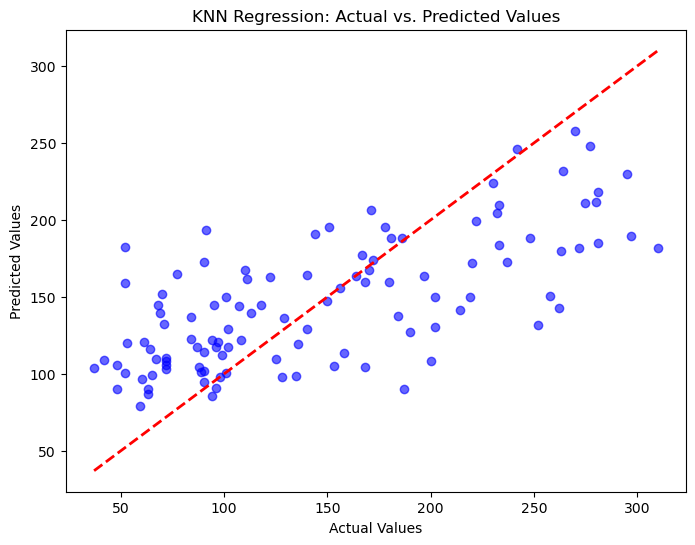

```python
plt.figure(figsize=(8, 6))
plt.scatter(y_test, y_pred, color='blue', alpha=0.6)
plt.plot([min(y_test), max(y_test)], [min(y_test), max(y_test)], color='red', linestyle='--', linewidth=2)  # Reference line
plt.xlabel("Actual Values")
plt.ylabel("Predicted Values")
plt.title("KNN Regression: Actual vs. Predicted Values")
plt.show()
```

## Diabetes Dataset Analysis Using K-Nearest Neighbors (KNN)

### 1. Loading the Diabetes Dataset

We load the diabetes dataset (`diabetes.csv`) using `pandas.read_csv()` and display the first few rows using `df.head()` to inspect the data structure.

```python
import pandas as pd
import numpy as np
import matplotlib.pyplot as plt
import seaborn as sns
from sklearn.model_selection import train_test_split
from sklearn.preprocessing import StandardScaler
from sklearn.neighbors import KNeighborsClassifier
from sklearn.metrics import accuracy_score, confusion_matrix, classification_report

df = pd.read_csv('diabetes.csv')

df.head()
```

|  | Pregnancies | Glucose | BloodPressure | SkinThickness | Insulin | BMI | DiabetesPedigreeFunction | Age | Outcome |
| --- | --- | --- | --- | --- | --- | --- | --- | --- | --- |
| 0 | 6 | 148 | 72 | 35 | 0 | 33.6 | 0.627 | 50 | 1 |
| 1 | 1 | 85 | 66 | 29 | 0 | 26.6 | 0.351 | 31 | 0 |
| 2 | 8 | 183 | 64 | 0 | 0 | 23.3 | 0.672 | 32 | 1 |
| 3 | 1 | 89 | 66 | 23 | 94 | 28.1 | 0.167 | 21 | 0 |
| 4 | 0 | 137 | 40 | 35 | 168 | 43.1 | 2.288 | 33 | 1 |

### 2. Exploring the Diabetes Dataset

Before applying machine learning models, we need to understand the structure, quality, and distribution of the data.

1. **Dataset Information (`df.info()`)**: Displays dataset structure, column data types, and memory usage.
2. **Summary Statistics (`df.describe()`)**: Provides descriptive statistics (mean, std, min, max, etc.) for numerical features.
3. **Checking for Missing Values (`df.isnull().sum()`)**: Identifies if any column contains missing values.
4. **Class Distribution (`df['Outcome'].value_counts()`)**: Shows the frequency of diabetic (1) and non-diabetic (0) cases.

By analyzing these aspects, we can determine if preprocessing steps like handling missing values, normalization, or class balancing are required.

```python
print("\nDataset information:")
print(df.info())

print("\nSummary statistics:")
print(df.describe())

print("\nMissing values per column:")
print(df.isnull().sum())

print("\nClass distribution (Outcome):")
print(df['Outcome'].value_counts())
```

```
Dataset information:
<class 'pandas.core.frame.DataFrame'>
RangeIndex: 768 entries, 0 to 767
Data columns (total 9 columns):
 #   Column                    Non-Null Count  Dtype
---  ------                    --------------  -----
 0   Pregnancies               768 non-null    int64
 1   Glucose                   768 non-null    int64
 2   BloodPressure             768 non-null    int64
 3   SkinThickness             768 non-null    int64
 4   Insulin                   768 non-null    int64
 5   BMI                       768 non-null    float64
 6   DiabetesPedigreeFunction  768 non-null    float64
 7   Age                       768 non-null    int64
 8   Outcome                   768 non-null    int64
dtypes: float64(2), int64(7)
memory usage: 54.1 KB
None

Summary statistics:
       Pregnancies     Glucose  BloodPressure  SkinThickness     Insulin  \
count   768.000000  768.000000     768.000000     768.000000  768.000000
mean      3.845052  120.894531      69.105469      20.536458   79.799479
std       3.369578   31.972618      19.355807      15.952218  115.244002
min       0.000000    0.000000       0.000000       0.000000    0.000000
25%       1.000000   99.000000      62.000000       0.000000    0.000000
50%       3.000000  117.000000      72.000000      23.000000   30.500000
75%       6.000000  140.250000      80.000000      32.000000  127.250000
max      17.000000  199.000000     122.000000      99.000000  846.000000

              BMI  DiabetesPedigreeFunction         Age     Outcome
count  768.000000                768.000000  768.000000  768.000000
mean    31.992578                  0.471876   33.240885    0.348958
std      7.884160                  0.331329   11.760232    0.476951
min      0.000000                  0.078000   21.000000    0.000000
25%     27.300000                  0.243750   24.000000    0.000000
50%     32.000000                  0.372500   29.000000    0.000000
75%     36.600000                  0.626250   41.000000    1.000000
max     67.100000                  2.420000   81.000000    1.000000

Missing values per column:
Pregnancies                 0
Glucose                     0
BloodPressure               0
SkinThickness               0
Insulin                     0
BMI                         0
DiabetesPedigreeFunction    0
Age                         0
Outcome                     0
dtype: int64

Class distribution (Outcome):
Outcome
0    500
1    268
Name: count, dtype: int64
```

#### Understanding the class distribution:

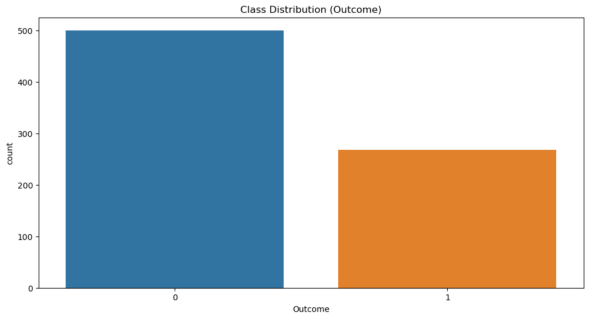

```python
plt.figure(figsize=(12, 6))
sns.countplot(x='Outcome', data=df)
plt.title('Class Distribution (Outcome)')
plt.show()
```

#### Visualizing the feature distribtions

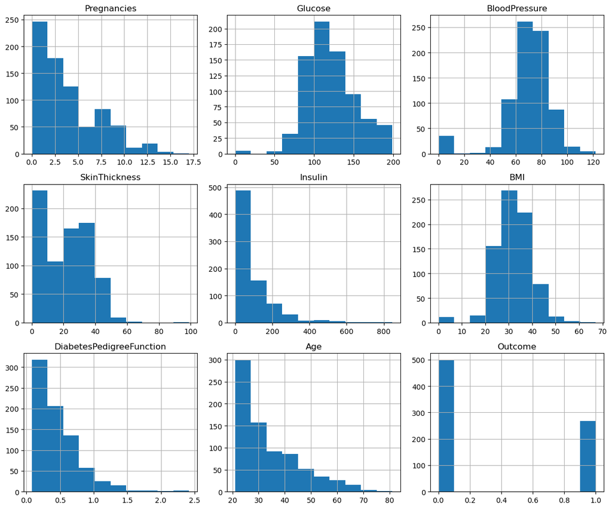

```python
df.hist(figsize=(12, 10))
plt.tight_layout()
plt.show()
```

#### Correlation matrix

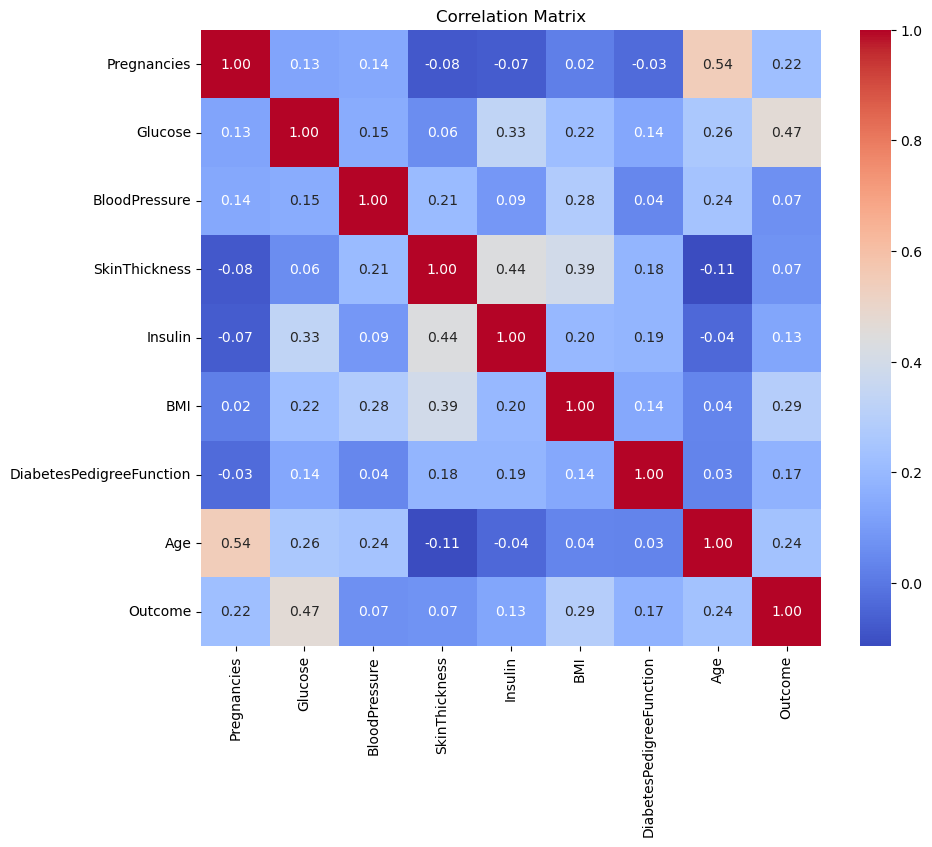

```python
plt.figure(figsize=(10, 8))
sns.heatmap(df.corr(), annot=True, cmap='coolwarm', fmt='.2f')
plt.title('Correlation Matrix')
plt.show()
```

### 3. Data Pre-processing:

1. **Handling Invalid Zeros**:
   - Some columns (e.g., `Glucose`, `BloodPressure`, `SkinThickness`, `Insulin`, `BMI`) contain biologically invalid zero values.
   - We replace zeros with the median of non-zero values for each column.
2. **Feature and Target Separation**:
   - `X`: Independent variables (all columns except `Outcome`).
   - `y`: Dependent variable (`Outcome` column, indicating diabetes presence).
3. **Train-Test Split**:
   - Splitting data into 80% training and 20% testing sets.
   - Using stratified sampling (`stratify=y`) to maintain class distribution.
4. **Feature Standardization**:
   - Since KNN is distance-based, we standardize features using `StandardScaler()`.
   - This ensures that all features have a mean of 0 and a standard deviation of 1.

```python
zero_columns = ['Glucose', 'BloodPressure', 'SkinThickness', 'Insulin', 'BMI']

for col in zero_columns:
    median_val = df[df[col] != 0][col].median()
    df[col] = df[col].replace(0, median_val)

X = df.drop('Outcome', axis=1)
y = df['Outcome']

X_train, X_test, y_train, y_test = train_test_split(
    X, y, test_size=0.2, random_state=42, stratify=y
)

scaler = StandardScaler()
X_train_scaled = scaler.fit_transform(X_train)
X_test_scaled = scaler.transform(X_test)

print("\nAfter handling zeros and scaling:")
print("\nSample scaled training data (first 5 rows):")
print(pd.DataFrame(X_train_scaled, columns=X.columns).head())
```

```
After handling zeros and scaling:

Sample scaled training data (first 5 rows):
   Pregnancies   Glucose  BloodPressure  SkinThickness   Insulin       BMI  \
0    -0.851355 -1.056427      -0.826740      -1.918187 -1.203361 -0.769477
1     0.356576  0.144399       0.477772      -0.229874 -1.470195 -0.417498
2    -0.549372 -0.556083      -1.152868       1.233330 -0.555335  0.359790
3    -0.851355  0.811525      -1.315932      -0.004766 -0.161437 -0.402832
4    -1.153338 -0.889646      -0.663676       1.120776 -0.415565  1.782373

   DiabetesPedigreeFunction       Age
0                  0.310794 -0.792169
1                 -0.116439  0.561034
2                 -0.764862 -0.707594
3                  0.262314 -0.369293
4                 -0.337630 -0.961320
```

### 4. Building the K-Nearest Neighbors (KNN) Model

Since KNN is sensitive to the number of neighbors (`k`), we determine the optimal `k` value by evaluating model accuracy.

1. Finding the Optimal `k`:
   - Train multiple KNN models with different values of `k` (from 1 to 30).
   - Compute and compare training and testing accuracy.
   - Identify the `k` that yields the highest test accuracy.
2. Plot Accuracy vs. k:
   - Visualize how accuracy changes as we vary `k`.
   - Look for the best balance between overfitting (low `k`) and underfitting (high `k`).
3. Train the Final KNN Model using the best `k`.

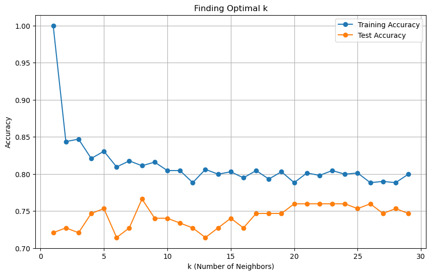

```
Optimal k: 8 (Test Accuracy: 0.77)
```

```
KNeighborsClassifier(n_neighbors=8)
```

```python
k_values = range(1, 30)
train_accuracies = []
test_accuracies = []

for k in k_values:
    knn = KNeighborsClassifier(n_neighbors=k)
    knn.fit(X_train_scaled, y_train)

    train_pred = knn.predict(X_train_scaled)
    train_acc = accuracy_score(y_train, train_pred)
    train_accuracies.append(train_acc)

    test_pred = knn.predict(X_test_scaled)
    test_acc = accuracy_score(y_test, test_pred)
    test_accuracies.append(test_acc)

plt.figure(figsize=(10, 6))
plt.plot(k_values, train_accuracies, label='Training Accuracy', marker='o')
plt.plot(k_values, test_accuracies, label='Test Accuracy', marker='o')
plt.xlabel('k (Number of Neighbors)')
plt.ylabel('Accuracy')
plt.title('Finding Optimal k')
plt.legend()
plt.grid(True)
plt.show()

best_k = k_values[np.argmax(test_accuracies)]
print(f"Optimal k: {best_k} (Test Accuracy: {test_accuracies[best_k-1]:.2f})")

final_knn = KNeighborsClassifier(n_neighbors=best_k)
final_knn.fit(X_train_scaled, y_train)
```

### 5. Model Evaluation

Evaluate the model performance on test set.

1. Test Accuracy: Measures the proportion of correctly classified instances.
2. Confusion Matrix:
3. Classification Report:

A high accuracy is desirable, but in medical diagnoses, recall and precision for the diabetic class (`1`) are also critical.

```
Test Accuracy: 0.77
```

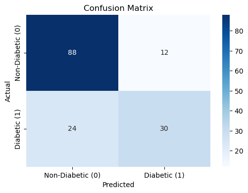

```
Classification Report:
              precision    recall  f1-score   support

           0       0.79      0.88      0.83       100
           1       0.71      0.56      0.62        54

    accuracy                           0.77       154
   macro avg       0.75      0.72      0.73       154
weighted avg       0.76      0.77      0.76       154
```

```python
y_pred = final_knn.predict(X_test_scaled)

accuracy = accuracy_score(y_test, y_pred)
print(f"Test Accuracy: {accuracy:.2f}")

cm = confusion_matrix(y_test, y_pred)
plt.figure(figsize=(6, 4))
sns.heatmap(cm, annot=True, fmt='d', cmap='Blues',
            xticklabels=['Non-Diabetic (0)', 'Diabetic (1)'],
            yticklabels=['Non-Diabetic (0)', 'Diabetic (1)'])
plt.xlabel('Predicted')
plt.ylabel('Actual')
plt.title('Confusion Matrix')
plt.show()

print("\nClassification Report:")
print(classification_report(y_test, y_pred))
```

### 6. Adjusting Classification Threshold for Better Sensitivity

The default threshold for classification in KNN (or most classifiers) is 0.5, meaning:

- If the predicted probability of being diabetic (`1`) is ≥ 0.5, the model classifies as diabetic (`1`).
- If the probability is < 0.5, the model classifies as non-diabetic (`0`).

However, in medical applications, recall (sensitivity) for detecting diabetes is critical. Missing diabetic cases (False Negatives) can have serious consequences.

1. Obtain Predicted Probabilities:
   - Instead of discrete class predictions (`0` or `1`), we retrieve the probability of class 1 (diabetic).
2. Set a Lower Threshold:
   - Reduce the decision threshold from 0.5 to 0.3 to increase recall.
   - This increases the model's tendency to predict diabetic (`1`).
3. Evaluate the Model with the New Threshold:
   - Compare precision, recall, and F1-score to assess trade-offs.

```python
y_probs = final_knn.predict_proba(X_test_scaled)[:, 1]

threshold = 0.3
y_pred_adjusted = (y_probs >= threshold).astype(int)

print("Adjusted Threshold Classification Report:")
print(classification_report(y_test, y_pred_adjusted))
```

```
Adjusted Threshold Classification Report:
              precision    recall  f1-score   support

           0       0.86      0.67      0.75       100
           1       0.57      0.80      0.66        54

    accuracy                           0.71       154
   macro avg       0.71      0.73      0.71       154
weighted avg       0.76      0.71      0.72       154
```

```python
class_weights = {0: 1, 1: 2}

weighted_knn = KNeighborsClassifier(
    n_neighbors=best_k,
    weights='distance'
)
weighted_knn.fit(X_train_scaled, y_train)

y_pred_weighted = weighted_knn.predict(X_test_scaled)
print("\nWeighted KNN Classification Report:")
print(classification_report(y_test, y_pred_weighted))
```

```
Weighted KNN Classification Report:
              precision    recall  f1-score   support

           0       0.79      0.84      0.81       100
           1       0.66      0.57      0.61        54

    accuracy                           0.75       154
   macro avg       0.72      0.71      0.71       154
weighted avg       0.74      0.75      0.74       154
```

### 8. Handling Class Imbalance Using SMOTE

The dataset may have an imbalance between diabetic (1) and non-diabetic (0) cases, leading to biased model predictions. To address this, we use Synthetic Minority Over-sampling Technique (SMOTE).

- Increases the number of diabetic cases (class 1) by generating synthetic examples.
- Unlike random oversampling, SMOTE avoids duplication by interpolating new samples between real ones.
- Applied only to the training set to prevent data leakage into the test set.

```python
from imblearn.over_sampling import SMOTE

smote = SMOTE(sampling_strategy='minority', random_state=42)
X_train_smote, y_train_smote = smote.fit_resample(X_train_scaled, y_train)

smote_knn = KNeighborsClassifier(n_neighbors=best_k)
smote_knn.fit(X_train_smote, y_train_smote)

y_pred_smote = smote_knn.predict(X_test_scaled)
print("\nSMOTE + KNN Classification Report:")
print(classification_report(y_test, y_pred_smote))
```

```
SMOTE + KNN Classification Report:
              precision    recall  f1-score   support

           0       0.80      0.71      0.75       100
           1       0.55      0.67      0.61        54

    accuracy                           0.69       154
   macro avg       0.68      0.69      0.68       154
weighted avg       0.71      0.69      0.70       154
```

### 9. Hyperparameter Tuning with GridSearchCV

To optimize the performance of our K-Nearest Neighbors (KNN) model, we use GridSearchCV to find the best combination of hyperparameters.

```python
from sklearn.model_selection import GridSearchCV

param_grid = {
    'n_neighbors': range(3, 15),
    'weights': ['uniform', 'distance'],
    'metric': ['euclidean', 'manhattan']
}

knn = KNeighborsClassifier()
grid_search = GridSearchCV(knn, param_grid, cv=5, scoring='recall')  # Prioritize recall for class 1
grid_search.fit(X_train_scaled, y_train)

best_params = grid_search.best_params_
best_knn = grid_search.best_estimator_
print(f"Best Parameters: {best_params}")
```

```
Best Parameters: {'metric': 'euclidean', 'n_neighbors': 10, 'weights': 'distance'}
```

### 10. Feature Selection Using ANOVA F-Test

To improve our KNN model's efficiency and performance, we use feature selection to retain only the most relevant features.

```python
from sklearn.feature_selection import SelectKBest, f_classif

selector = SelectKBest(score_func=f_classif, k=5)
X_train_selected = selector.fit_transform(X_train_scaled, y_train)
X_test_selected = selector.transform(X_test_scaled)

selected_features = X_train.columns[selector.get_support()]
print(f"Selected Features: {selected_features}")
```

```
Selected Features: Index(['Glucose', 'SkinThickness', 'Insulin', 'BMI', 'Age'], dtype='object')
```

### 11. Handling Class Imbalance with SMOTE-ENN

Since class imbalance can lead to biased predictions, we use SMOTE-ENN, a hybrid resampling technique that combines oversampling and undersampling.

- **SMOTE (Synthetic Minority Over-sampling Technique)**:
  - Generates synthetic examples for the minority class (`Diabetic = 1`).
- ENN (Edited Nearest Neighbors):
  - Removes noisy samples from both classes, improving data quality.
- Unlike basic SMOTE, SMOTE-ENN balances data dynamically by adding synthetic samples and removing outliers .

```python
from imblearn.combine import SMOTEENN

smote_enn = SMOTEENN(random_state=42)
X_train_balanced, y_train_balanced = smote_enn.fit_resample(X_train_scaled, y_train)

best_knn.fit(X_train_balanced, y_train_balanced)
```

```
KNeighborsClassifier(metric='euclidean', n_neighbors=10, weights='distance')
```

### 12. Final Evaluation of Optimized KNN Model

```
Optimized KNN Classification Report:
              precision    recall  f1-score   support

           0       0.86      0.65      0.74       100
           1       0.55      0.80      0.65        54

    accuracy                           0.70       154
   macro avg       0.70      0.72      0.70       154
weighted avg       0.75      0.70      0.71       154
```

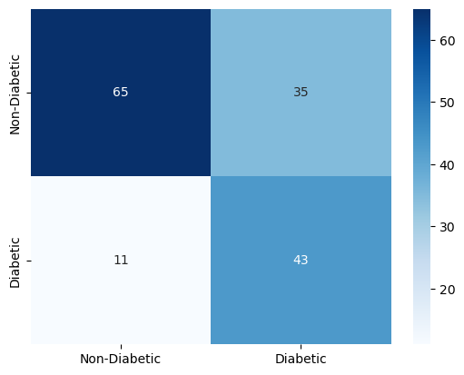

```python
y_pred_final = best_knn.predict(X_test_scaled)

print("\nOptimized KNN Classification Report:")
print(classification_report(y_test, y_pred_final))

cm = confusion_matrix(y_test, y_pred_final)
sns.heatmap(cm, annot=True, fmt='d', cmap='Blues',
            xticklabels=['Non-Diabetic', 'Diabetic'],
            yticklabels=['Non-Diabetic', 'Diabetic'])
plt.show()
```

To better understand how K-Nearest Neighbors (KNN) classifies data, we apply Principal Component Analysis (PCA) to reduce our high-dimensional feature space to 2 dimensions.

[figure not shown]

```python
from sklearn.decomposition import PCA

pca = PCA(n_components=2)
X_pca = pca.fit_transform(X_train_scaled)

plt.figure(figsize=(10, 6))
sns.scatterplot(x=X_pca[:, 0], y=X_pca[:, 1], hue=y_train, palette='viridis')
plt.title("KNN Decision Boundary (PCA-Reduced Features)")
plt.show()
```

# Requirements to run the Model

To ensure a seamless experience while running the K-Nearest Neighbors (KNN) model, the following system setup and dependencies must be met:

1. **Operating System Compatibility** The implementation is compatible with the following operating systems:
   - Windows (Windows 10 or later)
   - macOS (Monterey or later)
   - Linux (Ubuntu 20.04+ or equivalent)

   For best performance, it is recommended to use a system with at least 4GB RAM (8GB+ preferred) and a modern multi-core processor.
2. **Required Python Version** The project requires Python 3.8 or later. It is recommended to use the latest stable release (e.g., Python 3.10 or 3.11) to ensure compatibility with all libraries.
3. **Required Python Packages**

   To run the model successfully, install the following dependencies:
   - numpy 1.23.5
   - pandas 1.5.3
   - scikit-learn 1.2.2
   - matplotlib 3.6.3
   - seaborn 0.12.2
   - jupyterlab 3.6.1
4. **Hardware Recommendations**

   Minimum: 4GB RAM, Intel i3 / AMD Ryzen 3 Processor Recommended: 8GB RAM or higher, Intel i5/i7 / AMD Ryzen 5/7 Processor. If extending the project to deep learning, an NVIDIA GPU with CUDA support is beneficial.